# Replication of Study Parents’ Views of Failure Predict Children’s Fixed and Growth Intelligence Mind-Sets by Haimovitz, Kyla & Dweck, Carol S. (2016, Psychological Science)

Barbara Barbosa Born (bborn@stanford.edu)

December 28, 2017

## Introduction

Student’s educational development - both regarding academic achievement and personal growth - is the primary goal of schooling. Nevertheless, teachers are struggling to attain success in their intents educating children and adolescents because one’s learning is determined not only by the quality of the classes he or she attends but for the family context, socio-economic status, among other aspects. While it is impossible for teachers to reach all out-side schools variables that make student’s learning more difficult, it is possible to them to benefit from information regarding parents’ style of upbringing. In this sense, Haimovitz and Dweck’s (2016) study adds important contributions to the field of education. In this paper, the authors describe three studies that aimed to understand how parents’ “failure mind-set” is related to students “intelligence mind-sets” and what how the two types of failure mind-sets (failure as debilitating versus failure as enhancing) manifests.

The fourth study, in which the authors created an experiment manipulating the failure mindset of parents, is of particular interest for me. As a researcher interested in teacher education, to grasp these mechanisms is a form to gather information that can be used in teacher training to prepare them to interact with parents more constructively. Therefore, I am interested in replicating “study 04” in this paper, in which they were interested in identifying causal relations between failure mindset and reactions to children failure. In this study, parents receive as “treatment” a manipulation of failure mindset to be either “failure-as-debilitating” and “failure-as-enhancing”. They were asked, them, to react to students’ hypothetical failure situation. The authors recruited 132 parents through Amazon’s Mechanical Turk Web site. These participants answered a survey that assessed several beliefs, including their perceptions of their children’s competence.

## Methods

### Power Analysis

I calculated the power based on data provided by the paper. The results the authors reported are the following: “*Parents who were induced to hold a failure-is-debilitating mindset were more likely to react with concerns about their child’s performance and lack of ability, t(131) = 3.246, p < .001, np2= .075, and less likely to react with support for their child’s learning and mastery, t(131) = - 2.04, p = .043, np 2 = .031, compared with those who were induced to hold a failure-is-enhancing mindset*.”

In this replication, I am interested in analyze whether the results for the relation between failure-is-debilitating mindset and performance-oriented reactions hold. Therefore, I calculated the power based on the finding of the authors that parents who hold a failure-is-debilitating mindset are more likely to react with concerns about their child’s performance and lack of ability [t(131)=3.246, p<.001].

Original Effect size: Cohen’s d: **0.56721** Post-hoc power analysis for 132 subjects had shown that the original sample achieved **90%**.

The power analysis based on the effect size of differences between conditions in the number of mentions of child’s performance and lack of ability had shown the following sample size for each power: **80%** = 100 (50 per group) **90%** = 134 (67 per group) **95%** = 164 (82 per group)

For this replication, I intend to use the power of 80%.

[figure not shown]

Power Analysis.

### Planned Sample

Due to budget constraints, I will use a sample of 100 subjects (50 per group), achieving an 80% power. The sample will be drawn from Amazon Mechanical Turk. The selection criteria will be only people that live in the US and that have children.

To screen for parenthood status without using the premium qualifications, I adopted the following procedure. In the description of the task on Amazon Mechanical Turk, I wrote: “Parents Only.” When they start the survey on Qualtrics, I ask whether they are parents or not. Participants that answer “no” go straight to the end of the survey and no data is collected. To double check the liability of the answers, I added two questions at the end that ask participants to inform how many children they have and how old they are. They are told that the answer will not affect their pay. Therefore, if someone answers that has no child, This observation will be dropped from the final sample.

### Materials

For the replication, I used the materials provided by the authors in the Open Science Framework (https://osf.io/hb583/). More specifically, I used the questions for parents’ mindset from Study 01, as well as the biased questionaire for manipulating the failure mindset and the proposed case for them to react.

The survey was organized in Qualtrics format, and linked to Amazon Mechanical Turk.

This is the link for the survey: https://stanforduniversity.qualtrics.com/jfe/form/SV_dgwcLy8Q28UFQ0d

### Procedure

Procedures from the original paper:

> “Participants completed an online survey initially assessing several beliefs, including their perceptions of their child’s competence (assessed with same measure as in Study 1; alpha = .79). Then we temporarily manipulated failure mindsets by randomly assigning the parents to complete one of two five-item biased questionnaires, written to foster agreement with either a failure-is-debilitating mind-set (e.g.,”Experiencing failure can lead to negative feelings, like shame or sadness, that interfere with learning“) or a failure-is- enhancing mind-set (e.g.,”Experiencing failure can improve performance in the long run if you learn from it“). All measures used a 6-point rating scale from 1 (strongly disagree) to 6 (strongly agree). One-sample t tests comparing the mean in each priming condition with the scale’s midpoint (3.5) showed that participants’ agreement with the intended mind-set was above the midpoint in both the failure-is-debilitating condition (M = 4.41, SD = 1.07), t(56) = 6.45, p < .001, and the failure-is- enhancing condition (M = 5.14, SD = 0.829), t(74) = 17.11, p < .001. We then asked participants to read and vividly imagine a scenario in which their child came home from school with a failing grade on a math quiz, as in Study 2. They then wrote what they would do, think, and feel in response. Finally, participants reported on their failure mind-sets (alpha = .82), using the same items as in Study 1, as part of a survey that included a few other items”.

This procedure was followed precisely. The only adjustment is that I included a demographics section in my qualtrics survey since participants information is not available through Amazon MTurk.

### Analysis Plan

The analysis plan for this study is the following:

**Identification of agreement with priming condition (one-sample t-test)** * This test will verify whether parents’ answers to the priming condition are in agreement with the intended mindset. The t-test will compare the mean of each priming condition condition with the scale’s midpoint.

**Changes in parent’s failure mindset based on manipulation (t-test);** * This test intend to verify whether parents in the failure-is-debilitating priming condition report a failure-is-debilitating mindset. * This variable was constructed based on the mean of individual responses to the questionnaire of failure mindset. Lower scores indicate more of failure-is-debilitating mindset, whereas high scores indicate more of failure-is-enhancing mindset.

**Responses of parents to the situation based on their priming condition (t-test)**. * This is the statistic of interest of this replication. It will verify whether parents in the failure-is-debilitating mindset report more performance-oriented reactions than parents in the failure-is-enhancing. * The coding process to define performance and learning-oriented responses proceeds as follows. Using the coding scheeme developed by the authors, responses were coded into two categories: learning-oriented or performance-oriented.

> “Coders gave a score of 1 each time a code was present. Codes in the performance- oriented category were responses that focused on judg- ments of ability, particularly as a stable trait (e.g.,”I would think maybe my child is just not that good at math“); comfort for lack of ability (e.g.,”It’s ok that you got an F. You tried your best“); contingent self-worth based on their child’s performance (e.g.,”I’d feel bad about myself“); pity for their child’s lack of ability (”I would feel a little nervous for my child because I know how hard it can be“); grades as a goal (e.g.,”I would . . . hope their grades from previous [tests] are high enough to make up for the test“); and social comparison (”I would also want to know how the other children in the class scored“). Codes in the learning-oriented category were responses that focused on judgments of effort (e.g.,”I would tell my son he needs to study harder“); strategies, which included both general strategies (e.g.,”he didn’t study the material in the right way“) and specific study or test-taking strate- gies (e.g.,”I would also say that double checking your work before you hand it in is a good habit to get into“); help seeking (e.g.,”I would get her a math tutor“); mas- tery, or conceptual understanding, as a goal (e.g.,”the important thing we need to do is try to understand the concepts behind the problems he got wrong, and then study those“); interest (e.g.,”I would hope that the results of the test would not stop her from enjoying the class and wonder about ways I could help keep her liking of the subject going“); and explicit characterizations of failure as enhancing, or good (e.g.,”It is ok to make mistakes and fail sometimes, because that’s how people learn“).” (p. 866)

**Responses of parents to the situation based on their priming condition (linear regression) controlling for parents’ perception of their children’s competence.** * This analysis follow the same steps as the previous one, but controls for parents’ perception of their children’s competence.

**Clarify key analysis of interest here**

I will specifically look at the relation between failure-is-debilitating mindset and performance oriented responses.To address this relation, I will run a t.test comparing the mean of performance oriented responses between the two priming conditions. The test I will run is the following: t.test(perf_ori~condition,data = data.tidy)

### Differences from Original Study

I do not expect substantial differences from the original study based on these changes in terms of direction and significance of the results, but maybe the magnitude can be different.

### Methods Addendum (Post Data Collection)

You can comment this section out prior to final report with data collection.

#### Actual Sample

The survey was administered to 108 subjects, but the final sample totalized **97 observations**. 11 observations were excluded. Eight observations were dropped because the subjects did not answer to the failure situation. Three observations were dropped because the subjects reported having no child in the question at the end of the survey.

#### Differences from pre-data collection methods plan

There was no difference in the pre-data collection methods and the methods used in the final replication.

## Results

### Data preparation

Data preparation following the analysis plan.

```r
###Data Preparation

####Load Relevant Libraries and Functions
library(tidyverse) # for data munging
library(knitr) # for kable table formating
library(haven) # import and export 'SPSS', 'Stata' and 'SAS' Files
library(readxl) # import excel files
####Import data
setwd("/Users/babi-/Google Drive/Stanford PhD/2017-18/Fall 2017/PSYCH 251/Final project/Haimovitz2016/")
rm(list = ls())
data <- read.csv("Failure Mindset Replicaton_FinalData_Clean_Final.csv", header = FALSE, sep = ",")

#### Data exclusion / filtering

data.tidy <- data %>%
  rename(subj_id=V1,parent=V2, agreement=V3,
         inte_mind_01=V4, inte_mind_02=V5, inte_mind_03=V6, inte_mind_04=V7,
         perc_chil_01=V8, perc_chil_02=V9, perc_chil_03=V10, perc_chil_04=V11,
         cond_deb_01=V12, cond_deb_02=V13, cond_deb_03=V14,
         cond_deb_04=V15, cond_deb_05=V16,
         cond_enh_01=V17, cond_enh_02=V18, cond_enh_03=V19, cond_enh_04=V20,
         cond_enh_05=V21,
         say_chil=V22, think=V23, feel=V24,
         perf_ori=V25, lear_ori=V26,other=V27,
         fail_mind_01=V28, fail_mind_02=V29, fail_mind_03=V30,
         fail_mind_04=V31, fail_mind_05=V32, fail_mind_06=V33,
         educ=V34, gender=V35, origin=V36,age=V37,
         num_chil=V38, age_chil_01=V39, age_chil_02=V40, age_chil_03=V41, age_chil_04=V42,age_chil_05=V43, mTurk_id=V44, RT=V45)


data.tidy = data.tidy[-1,]
temp = rep(0,nrow(data.tidy))
temp[data.tidy$educ=="post-graduate degree"]=4
temp[data.tidy$educ=="college degree"]=3
temp[data.tidy$educ=="a high school degree"]=2
temp[data.tidy$educ=="no degrees"]=1

data.tidy$educ = temp

##Transforming factors into numerical variables

data.tidy$inte_mind_01<- as.numeric(as.character(data.tidy$inte_mind_01))
data.tidy$inte_mind_02<- as.numeric(as.character(data.tidy$inte_mind_02))
data.tidy$inte_mind_03<- as.numeric(as.character(data.tidy$inte_mind_03))
data.tidy$inte_mind_04<- as.numeric(as.character(data.tidy$inte_mind_04))
data.tidy$perc_chil_01<- as.numeric(as.character(data.tidy$perc_chil_01))
data.tidy$perc_chil_02<- as.numeric(as.character(data.tidy$perc_chil_02))
data.tidy$perc_chil_03<- as.numeric(as.character(data.tidy$perc_chil_03))
data.tidy$perc_chil_04<- as.numeric(as.character(data.tidy$perc_chil_04))
data.tidy$cond_deb_01<-as.numeric(as.character(data.tidy$cond_deb_01))
data.tidy$cond_deb_02<-as.numeric(as.character(data.tidy$cond_deb_02))
data.tidy$cond_deb_03<-as.numeric(as.character(data.tidy$cond_deb_03))
data.tidy$cond_deb_04<-as.numeric(as.character(data.tidy$cond_deb_04))
data.tidy$cond_deb_05<-as.numeric(as.character(data.tidy$cond_deb_05))
data.tidy$cond_enh_01<-as.numeric(as.character(data.tidy$cond_enh_01))
data.tidy$cond_enh_02<-as.numeric(as.character(data.tidy$cond_enh_02))
data.tidy$cond_enh_03<-as.numeric(as.character(data.tidy$cond_enh_03))
data.tidy$cond_enh_04<-as.numeric(as.character(data.tidy$cond_enh_04))
data.tidy$cond_enh_05<-as.numeric(as.character(data.tidy$cond_enh_05))
data.tidy$fail_mind_01<-as.numeric(as.character(data.tidy$fail_mind_01))
data.tidy$fail_mind_02<-as.numeric(as.character(data.tidy$fail_mind_02))
data.tidy$fail_mind_03<-as.numeric(as.character(data.tidy$fail_mind_03))
data.tidy$fail_mind_04<-as.numeric(as.character(data.tidy$fail_mind_04))
data.tidy$fail_mind_05<-as.numeric(as.character(data.tidy$fail_mind_05))
data.tidy$fail_mind_06<-as.numeric(as.character(data.tidy$fail_mind_06))
data.tidy$perf_ori<-as.numeric(as.character(data.tidy$perf_ori))
data.tidy$lear_ori<-as.numeric(as.character(data.tidy$lear_ori))
data.tidy$age<-as.numeric(as.character(data.tidy$age))
data.tidy$RT<-as.numeric(as.character(data.tidy$RT))


#### Prepare data for analysis - create columns etc.
#create the column names
names <- names(data.tidy)

data.tidy$int_min_mean = apply(data.tidy[,which(names=="inte_mind_01"):which(names=="inte_mind_04")],1,mean)

data.tidy$per_chi_mean = apply(data.tidy[,which(names=="perc_chil_01"):which(names=="perc_chil_04")],1,mean)

data.tidy$cond_deb_mean = apply(data.tidy[,which(names=="cond_deb_01"):which(names=="cond_deb_05")],1,mean)

data.tidy$cond_enh_mean = apply(data.tidy[,which(names=="cond_enh_01"):which(names=="cond_enh_05")],1,mean)

data.tidy$fai_post_mean = apply(data.tidy[,which(names=="fail_mind_01"):which(names=="fail_mind_04")],1,mean)

###Creating the dummy for the condition
condition <- rep("Failure is Enhancing",97)
condition[is.na(data.tidy$cond_enh_mean)] <- "Failure is Debilitating"

data.tidy$condition <- condition
data.tidy$condition <-as.factor(data.tidy$condition)
```

```r
##Demographics

temp = rep(0, nrow(data.tidy))
temp[data.tidy$gender=="Female"]=1
temp[data.tidy$gender=="Male"]=0

data.tidy$gender=temp

mean(data.tidy$gender)
```

```
## [1] 0.4948454
```

```r
summary(data.tidy$age)[4]
```

```
## Mean
##   36
```

```r
table(data.tidy$educ)
```

```
##
##  2  3  4
## 27 57 13
```

```r
table(data.tidy$origin)
```

```
##
## African American   Asian American         Hispanic           Origin
##                2                5               11                0
##            Other            White
##                3               76
```

### Confirmatory analysis

The analyses as specified in the analysis plan.

```r
### Sumary statistics
sem <- function(x) {sd(x, na.rm=TRUE) / sqrt(sum(!is.na((x))))}
ci <- function(x) {sem(x) * 1.96}

ms <- data.tidy %>%
    group_by(condition, subj_id) %>%
    summarise(intel_mind = mean(int_min_mean)) %>%    # get subject means
    group_by(condition) %>%
    summarise(mean.intel_mind = mean(intel_mind),
              sd = sd(intel_mind), "ci"= ci(intel_mind))
knitr::kable(ms, digits = 2)
```

| condition | mean.intel_mind | sd | ci |
| --- | --- | --- | --- |
| Failure is Debilitating | 3.52 | 0.64 | 0.18 |
| Failure is Enhancing | 3.68 | 0.52 | 0.15 |

```r
ms <- data.tidy %>%
    group_by(condition, subj_id) %>%
    summarise(percep_chil = mean(per_chi_mean)) %>%    # get subject means
    group_by(condition) %>%
    summarise(mean.percep_chil = mean(percep_chil),
              sd = sd(percep_chil), "ci"= ci(percep_chil))

knitr::kable(ms, digits = 2)
```

| condition | mean.percep_chil | sd | ci |
| --- | --- | --- | --- |
| Failure is Debilitating | 4.44 | 0.96 | 0.27 |
| Failure is Enhancing | 4.52 | 0.87 | 0.24 |

```r
ms <- data.tidy %>%
    group_by(condition, subj_id) %>%
    summarise(cond_debil = mean(cond_deb_mean)) %>%    # get subject means
    group_by(condition) %>%
    summarise(mean.cond_debil = mean(cond_debil),
              sd = sd(cond_debil), "ci"= ci(cond_debil))

knitr::kable(ms, digits = 2)
```

| condition | mean.cond_debil | sd | ci |
| --- | --- | --- | --- |
| Failure is Debilitating | 3.87 | 0.88 | 0.25 |
| Failure is Enhancing | NA | NaN | NA |

```r
ms <- data.tidy %>%
    group_by(condition, subj_id) %>%
    summarise(cond_enha = mean(cond_enh_mean)) %>%    # get subject means
    group_by(condition) %>%
    summarise(mean.cond_enha = mean(cond_enha),
              sd = sd(cond_enha), "ci"= ci(cond_enha))

knitr::kable(ms, digits = 2)
```

| condition | mean.cond_enha | sd | ci |
| --- | --- | --- | --- |
| Failure is Debilitating | NA | NaN | NA |
| Failure is Enhancing | 5.11 | 0.87 | 0.25 |

```r
ms <- data.tidy %>%
    group_by(condition, subj_id) %>%
    summarise(perf_orie = mean(perf_ori)) %>%    # get subject means
    group_by(condition) %>%
    summarise(mean.perf_orie = mean(perf_orie),
              sd = sd(perf_orie), "ci"= ci(perf_orie))

knitr::kable(ms, digits = 2)
```

| condition | mean.perf_orie | sd | ci |
| --- | --- | --- | --- |
| Failure is Debilitating | 0.65 | 0.69 | 0.19 |
| Failure is Enhancing | 0.94 | 0.76 | 0.21 |

```r
ms <- data.tidy %>%
    group_by(condition, subj_id) %>%
    summarise(learn_orie = mean(lear_ori)) %>%    # get subject means
    group_by(condition) %>%
    summarise(mean.learn_orie = mean(learn_orie),
              sd = sd(learn_orie), "ci"= ci(learn_orie))

knitr::kable(ms, digits = 2)
```

| condition | mean.learn_orie | sd | ci |
| --- | --- | --- | --- |
| Failure is Debilitating | 1.67 | 0.77 | 0.22 |
| Failure is Enhancing | 1.71 | 0.82 | 0.23 |

```r
ms <- data.tidy %>%
    group_by(condition, subj_id) %>%
    summarise(fail_mind = mean(fai_post_mean)) %>%    # get subject means
    group_by(condition) %>%
    summarise(mean.fail_mind = mean(fail_mind),
              sd = sd(fail_mind), "ci"= ci(fail_mind))

knitr::kable(ms, digits = 2)
```

| condition | mean.fail_mind | sd | ci |
| --- | --- | --- | --- |
| Failure is Debilitating | 4.01 | 0.85 | 0.24 |
| Failure is Enhancing | 4.19 | 0.78 | 0.22 |

```r
###Agreement with the condition

#Failure is debilitating condition
t.test(data.tidy$cond_deb_mean, mu=3.5, conf.level=0.95)
```

```
##
##  One Sample t-test
##
## data:  data.tidy$cond_deb_mean
## t = 2.8942, df = 48, p-value = 0.005703
## alternative hypothesis: true mean is not equal to 3.5
## 95 percent confidence interval:
##  3.611523 4.119089
## sample estimates:
## mean of x
##  3.865306
```

```r
#Failure is enhancing condition
t.test(data.tidy$cond_enh_mean, mu=3.5, conf.level=0.95)
```

```
##
##  One Sample t-test
##
## data:  data.tidy$cond_enh_mean
## t = 12.896, df = 47, p-value < 2.2e-16
## alternative hypothesis: true mean is not equal to 3.5
## 95 percent confidence interval:
##  4.860952 5.364048
## sample estimates:
## mean of x
##    5.1125
```

```r
# compare the change in the failure mindset according to the prime condition
t.test(fai_post_mean ~ condition, data = data.tidy)
```

```
##
##  Welch Two Sample t-test
##
## data:  fai_post_mean by condition
## t = -1.1027, df = 94.704, p-value = 0.2729
## alternative hypothesis: true difference in means is not equal to 0
## 95 percent confidence interval:
##  -0.5107864  0.1459904
## sample estimates:
## mean in group Failure is Debilitating
##                              4.005102
##    mean in group Failure is Enhancing
##                              4.187500
```

```r
### Anaysis of priming condition in perforance and learning oriented responses

#### t.test for performace oriented
t.test(perf_ori~condition,data = data.tidy)
```

```
##
##  Welch Two Sample t-test
##
## data:  perf_ori by condition
## t = -1.9306, df = 93.953, p-value = 0.05655
## alternative hypothesis: true difference in means is not equal to 0
## 95 percent confidence interval:
##  -0.57697553  0.00809798
## sample estimates:
## mean in group Failure is Debilitating
##                             0.6530612
##    mean in group Failure is Enhancing
##                             0.9375000
```

```r
#### t.test for learning oriented
t.test(lear_ori~condition,data = data.tidy)
```

```
##
##  Welch Two Sample t-test
##
## data:  lear_ori by condition
## t = -0.21465, df = 94.349, p-value = 0.8305
## alternative hypothesis: true difference in means is not equal to 0
## 95 percent confidence interval:
##  -0.3573474  0.2876195
## sample estimates:
## mean in group Failure is Debilitating
##                              1.673469
##    mean in group Failure is Enhancing
##                              1.708333
```

```r
# controlling for parents' perception of child's competece
Performance <- lm(perf_ori~condition+per_chi_mean, data = data.tidy)
summary(Performance)
```

```
##
## Call:
## lm(formula = perf_ori ~ condition + per_chi_mean, data = data.tidy)
##
## Residuals:
##      Min       1Q   Median       3Q      Max
## -1.05623 -0.62434  0.08449  0.37566  2.13139
##
## Coefficients:
##                               Estimate Std. Error t value Pr(>|t|)
## (Intercept)                    1.06995    0.37636   2.843  0.00548 **
## conditionFailure is Enhancing  0.29117    0.14707   1.980  0.05065 .
## per_chi_mean                  -0.09381    0.08143  -1.152  0.25225
## ---
## Signif. codes:  0 '***' 0.001 '**' 0.01 '*' 0.05 '.' 0.1 ' ' 1
##
## Residual standard error: 0.7236 on 94 degrees of freedom
## Multiple R-squared:  0.05121,    Adjusted R-squared:  0.03102
## F-statistic: 2.537 on 2 and 94 DF,  p-value: 0.08452
```

```r
Learning <- lm(lear_ori~condition+per_chi_mean, data = data.tidy)
summary(Learning)#
```

```
##
## Call:
## lm(formula = lear_ori ~ condition + per_chi_mean, data = data.tidy)
##
## Residuals:
##     Min      1Q  Median      3Q     Max
## -1.7111 -0.6745  0.2916  0.3282  1.3309
##
## Coefficients:
##                                Estimate Std. Error t value Pr(>|t|)
## (Intercept)                    1.697626   0.417916   4.062 0.000101 ***
## conditionFailure is Enhancing  0.035254   0.163307   0.216 0.829552
## per_chi_mean                  -0.005436   0.090426  -0.060 0.952193
## ---
## Signif. codes:  0 '***' 0.001 '**' 0.01 '*' 0.05 '.' 0.1 ' ' 1
##
## Residual standard error: 0.8035 on 94 degrees of freedom
## Multiple R-squared:  0.0005238,  Adjusted R-squared:  -0.02074
## F-statistic: 0.02463 on 2 and 94 DF,  p-value: 0.9757
```

*Side-by-side graph with original graph is ideal here*

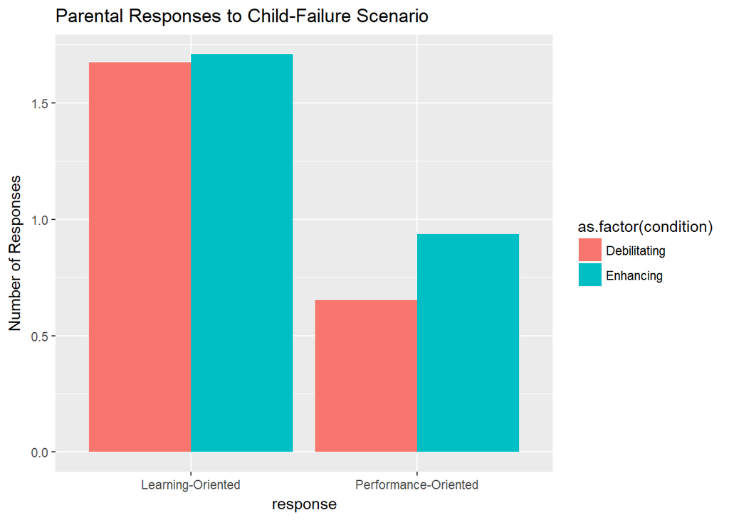

```r
# Graph
# Create table
graph_data <- tribble(
  ~response, ~ condition, ~mean, ~sd,
  # row 1
  "Performance-Oriented", "Debilitating", mean(data.tidy$perf_ori[data.tidy$condition=="Failure is Debilitating"]), sd(data.tidy$perf_ori[data.tidy$condition=="Failure is Debilitating"]),
  # row 2
"Performance-Oriented", "Enhancing", mean(data.tidy$perf_ori[data.tidy$condition=="Failure is Enhancing"]), sd(data.tidy$perf_ori[data.tidy$condition=="Failure is Enhancing"]),
  # row 3
  "Learning-Oriented", "Debilitating", mean(data.tidy$lear_ori[data.tidy$condition=="Failure is Debilitating"]), sd(data.tidy$lear_ori[data.tidy$condition=="Failure is Debilitating"]),
  # row 4
"Learning-Oriented", "Enhancing", mean(data.tidy$lear_ori[data.tidy$condition=="Failure is Enhancing"]), sd(data.tidy$lear_ori[data.tidy$condition=="Failure is Enhancing"]))

graph_data <- graph_data %>%
  mutate(max = mean + sd*1.96, min = mean - 1.96*sd)

# graph without bars
ggplot(data = graph_data, aes(x = response, y = mean, fill = as.factor(condition))) +
  geom_bar( stat = "identity", position = "dodge") +
  labs(title="Parental Responses to Child-Failure Scenario", y="Number of Responses")
```

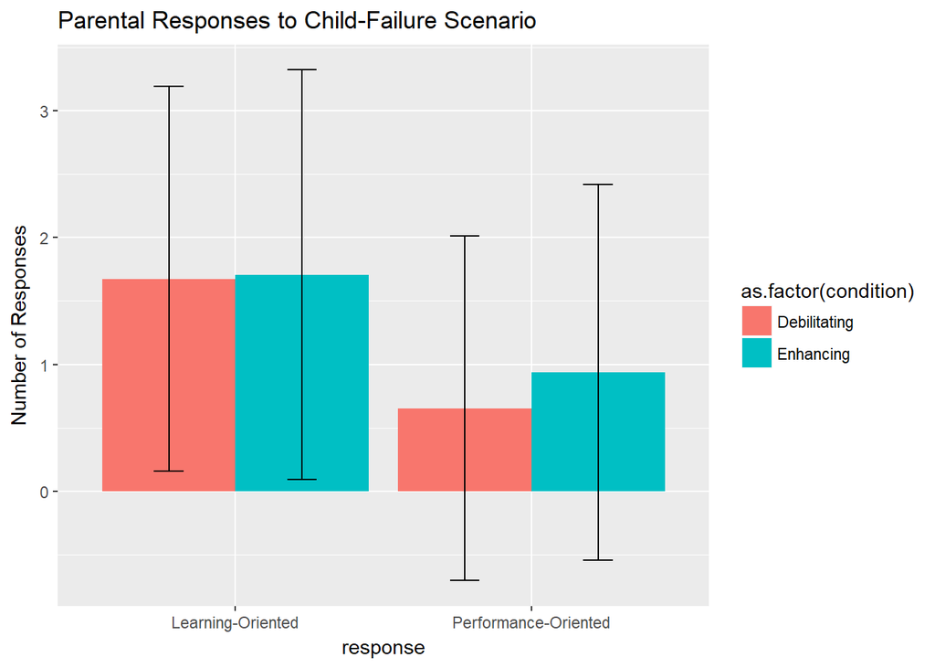

```r
# graph with bars
ggplot(data = graph_data, aes(x = response, y = mean, fill = as.factor(condition))) +
  geom_bar( stat = "identity", position = "dodge")  +
  geom_errorbar(aes(ymin=min, ymax=max),
                width=.2,                    # Width of the error bars
                position=position_dodge(.9))+
  labs(title="Parental Responses to Child-Failure Scenario", y="Number of Responses")
```

## Discussion

### Summary of Replication Attempt

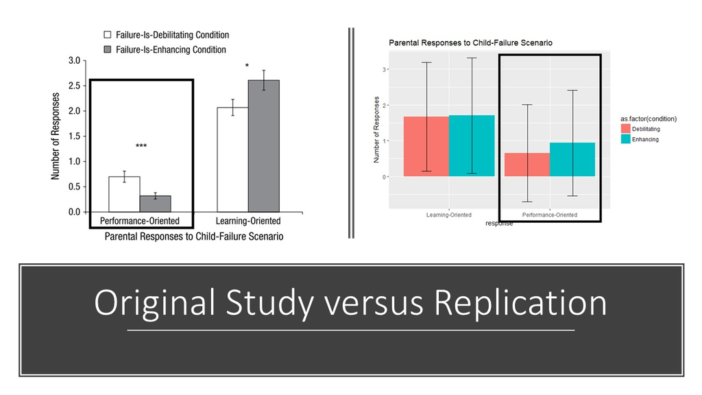

Comparison.

This replication attempt **failed to replicate** the original findings from the original study.

### Commentary

As stated above, this replication attempt failed to replicate the results from the original study, despite following the same procedures as the original one. Two differences, nevertheless, may have some influence on the results. We did not use the premium qualifications from Amazon Mechanical Turk, and therefore our sample can have some subjects that did not have child indeed. Additionally, our sample is slightly smaller than the original. Additional attempts may be necessary to verify whether results hold or not in different circumstances. It is interesting to notice, however, that the manipulation of the failure mindset does not seem to influence whether the parent has a performence- or learning- oriented response to failure. Therefore, it would be interesting to investigate different variables that can have influence on such responses.